# Projeto Integrador

### Partial Dependence Plots

Without getting into much details in the analysis of the partial dependence plots and ICE plots, it can be seems that the selected variables are are behaving as expected, for example, for the **sig_growth_sales_2012_2011**, which is the most important variable, the higher the value the lower is the probability of default. That suggests that most companies that defaults have a bad year of sales, compared to the previous year, before actually defaulting. The other thing that interesting to highlight is strange beahviours seems in the plots could, in fact, be due to the lack of data. Taking the ICE curve of the **sig_profit_margin_2012** as an example, it seems odd that the probability of default increases for high values of this feature, meaning that companies that are more profitable have a higher probability of defaulting. Looking at the rug plot at the bottom of this same graph we see that, in fact, the is a low density of data in the region mentioned, indicating that this behaviour could actually be a distortion caused by few observation, for example, companies that had few sales (small denominator), even though it was profitable for the amount of sales (resulting a high ration between profit and sales), and that were faded to default.

```r
# Creating an explanatory object
explainer_object <- explain(model = best_gbm, # model
                            data = dt_tt, # test data - probability
                            y = dt_tt$default # test data - target variable
                            )
```

[output not shown]

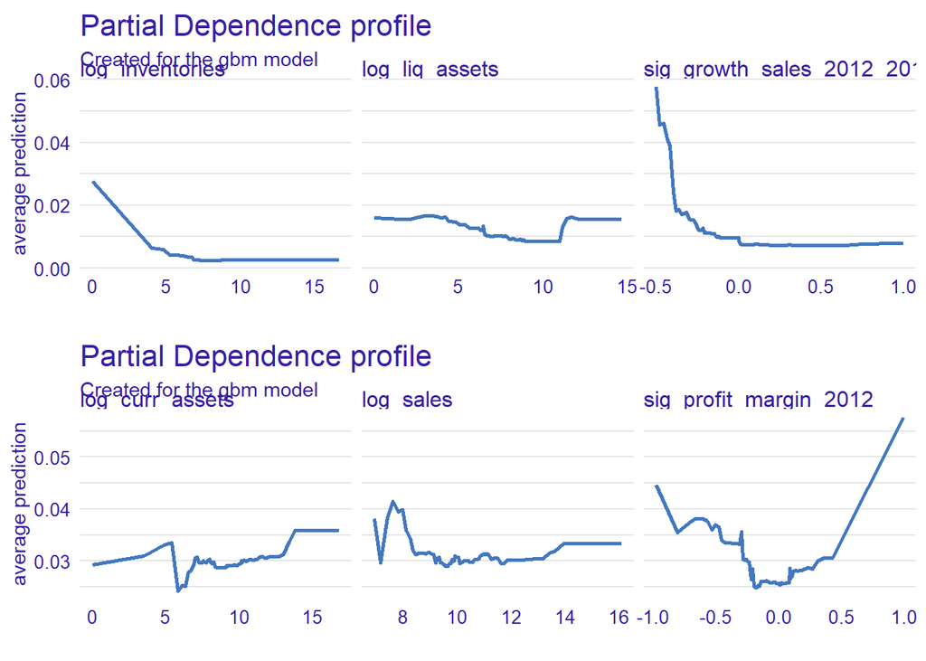

```r
# Create a plot Object of Partial Dependence Plots (PDP)
pdp_gbm_01 <- model_profile(explainer = explainer_object, variables = c("sig_growth_sales_2012_2011",
                                                                       "log_inventories",
                                                                       "log_liq_assets")) %>%  plot()

pdp_gbm_02 <- model_profile(explainer = explainer_object, variables = c("sig_profit_margin_2012",
                                                                       "log_sales",
                                                                       "log_curr_assets")) %>%  plot()
grid.arrange(pdp_gbm_01, pdp_gbm_02, ncol = 1, nrow = 2)
```

```r
pdp1 <- best_gbm %>%
  partial(pred.var = "sig_growth_sales_2012_2011", n.trees = 3000, rid.resolution = 100, train = dt_tr) %>%
  autoplot(rug = TRUE, train = dt_tr)
  ggtitle("PDP")
```

```
## $title
## [1] "PDP"
##
## attr(,"class")
## [1] "labels"
```

```r
ice1 <- best_gbm %>%
  partial(pred.var = "sig_growth_sales_2012_2011", n.trees = 3000, grid.resolution = 100, train = dt_tr, ice = TRUE) %>%
  autoplot(rug = TRUE, train = dt_tr, alpha = .01, center = TRUE)
  ggtitle("ICE")
```

```
## $title
## [1] "ICE"
##
## attr(,"class")
## [1] "labels"
```

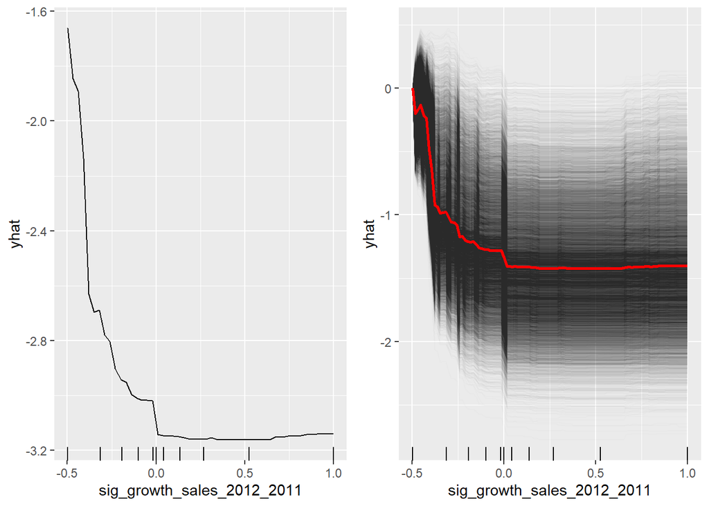

```r
gridExtra::grid.arrange(pdp1, ice1, nrow = 1)
```

```r
pdp2 <- best_gbm %>%
  partial(pred.var = "log_inventories", n.trees = 3000, rid.resolution = 100, train = dt_tr) %>%
  autoplot(rug = TRUE, train = dt_tr)
  ggtitle("PDP")
```

```
## $title
## [1] "PDP"
##
## attr(,"class")
## [1] "labels"
```

```r
ice2 <- best_gbm %>%
  partial(pred.var = "log_inventories", n.trees = 3000, grid.resolution = 100, train = dt_tr, ice = TRUE) %>%
  autoplot(rug = TRUE, train = dt_tr, alpha = .01, center = TRUE)
  ggtitle("ICE")
```

```
## $title
## [1] "ICE"
##
## attr(,"class")
## [1] "labels"
```

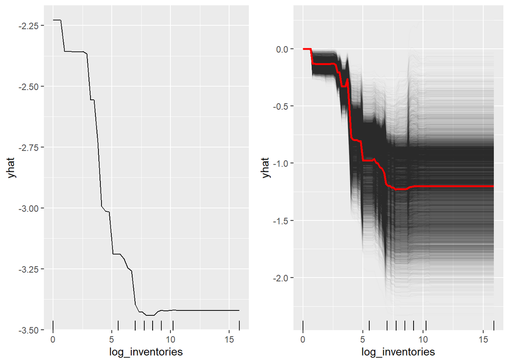

```r
gridExtra::grid.arrange(pdp2, ice2, nrow = 1)
```

```r
pdp3 <- best_gbm %>%
  partial(pred.var = "log_liq_assets", n.trees = 3000, rid.resolution = 100, train = dt_tr) %>%
  autoplot(rug = TRUE, train = dt_tr)
  ggtitle("PDP")
```

```
## $title
## [1] "PDP"
##
## attr(,"class")
## [1] "labels"
```

```r
ice3 <- best_gbm %>%
  partial(pred.var = "log_liq_assets", n.trees = 3000, grid.resolution = 100, train = dt_tr, ice = TRUE) %>%
  autoplot(rug = TRUE, train = dt_tr, alpha = .01, center = TRUE)
  ggtitle("ICE")
```

```
## $title
## [1] "ICE"
##
## attr(,"class")
## [1] "labels"
```

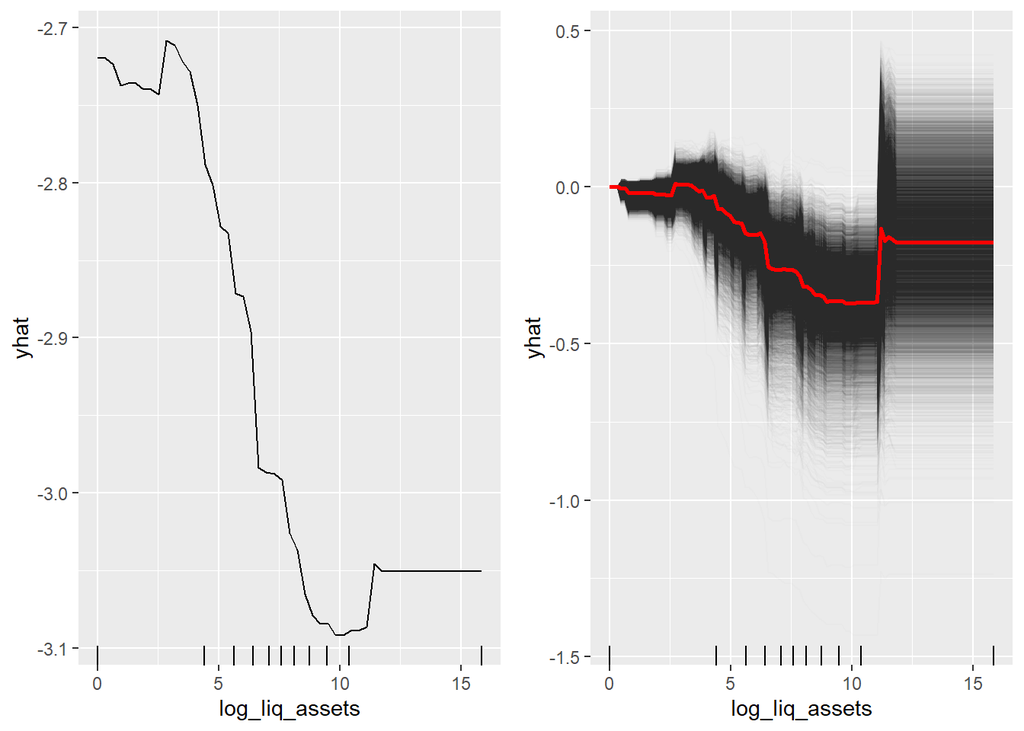

```r
gridExtra::grid.arrange(pdp3, ice3, nrow = 1)
```

```r
pdp4 <- best_gbm %>%
  partial(pred.var = "sig_profit_margin_2012", n.trees = 3000, rid.resolution = 100, train = dt_tr) %>%
  autoplot(rug = TRUE, train = dt_tr)
  ggtitle("PDP")
```

```
## $title
## [1] "PDP"
##
## attr(,"class")
## [1] "labels"
```

```r
ice4 <- best_gbm %>%
  partial(pred.var = "sig_profit_margin_2012", n.trees = 3000, grid.resolution = 100, train = dt_tr, ice = TRUE) %>%
  autoplot(rug = TRUE, train = dt_tr, alpha = .01, center = TRUE)
  ggtitle("ICE")
```

```
## $title
## [1] "ICE"
##
## attr(,"class")
## [1] "labels"
```

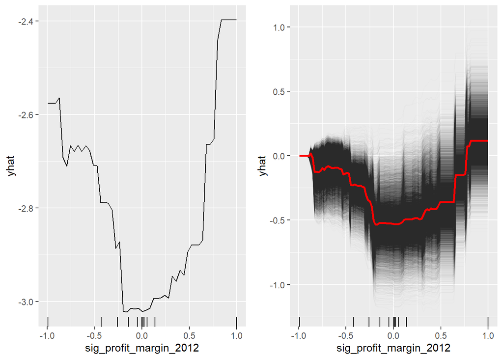

```r
gridExtra::grid.arrange(pdp4, ice4, nrow = 1)
```

### Best model from a business perspective

This section will be left for future work.

```r
for (t in seq(0, 1, 0.01)){

  tb_lg <- metrics_table(t, dt_tt$default,yhat_lg_tt)
  tb_lasso <- metrics_table(t, dt_tt$default, yhat_lg_lasso_tt)
  tb_rf <- metrics_table(t, dt_tt$default, yhat_tt_rf$predictions)
  tb_gbm <- metrics_table(t, dt_tt$default, yhat_gbm_tt)
  tb_xgb <- metrics_table(t, dt_tt$default, yhat_tt_xgb)
}
result_business <- tibble(
max_cm_lg    = tb_lg$values[tb_lg$metric == "Custom Metric"],
max_cm_lasso = tb_lasso$values[tb_lasso$metric == "Custom Metric"],
max_cm_rf    = tb_rf$values[tb_rf$metric == "Custom Metric"],
max_cm_gbm   = tb_gbm$values[tb_gbm$metric == "Custom Metric"],
max_cm_xgb   = tb_xgb$values[tb_xgb$metric == "Custom Metric"]
)
```

### Reference

BÉKÉS, G., KÉZDI, G. **Data analysis for business, economics, and policy**. United Kingdom: Cambridge University Press, 2021. p. 472.

BOEHMKE, B. **Gradient Boosting Machines**. UC Business Analytics R Programming Guide. 14 jun. 2018. Available in: http://uc-r.github.io/gbm_regression. Acessed on 22 mar. 2022.

**Bisnode Firms**. OSF Reasearch. 14 jun. 2018. Available in: https://osf.io/9a3t4/?pid=b2ft9. Acessed on 22 mar. 2022.